# Week 3: Syntax Guide

- Week 3: Syntax Guide
  - If Statement
  - If Else Statement
  - Enumeration Declaration
  - While Loop
  - Do While Loop
  - Switch (Case Statement)
- Example Code

## If Statement

Very often in code, we need to make a decision based upon some information. The mechanism to do this is known as the `if` statement.

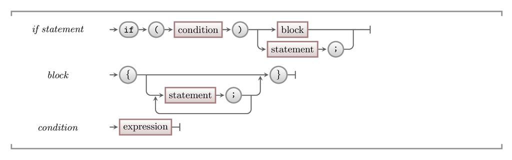

This diagram shows the syntax for a if statement in C#.

- The `condition` needs to evaluate to a **boolean** value (true or false).
- The block within the if is only executed *if* the condition is true.

```
using System;
using SplashKitSDK;

namespace MyProgram
{
  public class Main
  {
    public static void Main()
    {
      int age = ...;
      if (age > 18);
      {
        Console.WriteLine("Party time");
      }
    }
  }
}
```

## If Else Statement

The if statement can have an optional `else` path that allows us to specify two blocks of code: one that runs if a condition is `true`, and another when the condition is `false`.

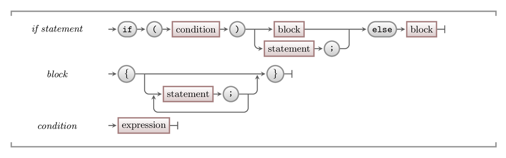

This diagram shows the syntax for a compound if else statement in C#.

The following code is an example of a if else statement in C#. This code shows "Party Time" **if** the age is larger than 18, and the day is Friday or Saturday. Otherwise (**else**) it prints the text "Study time".

```
using System;
using SplashKitSDK;

namespace MyProgram
{
  public class Main
  {
    public static void Main()
    {
      int age = ...;
      Day day = Day.Tuesday;

      if ( age > 18 && ( day == Day.Friday || day == Day.Saturday ))
      {
        Console.WriteLine("Party time");
      }
      else
      {
        Conosole.WriteLine("Study time");
      }
    }
  }
}
```

## Enumeration Declaration

Enumerations are a custom type used when we want to have a list of possible values.

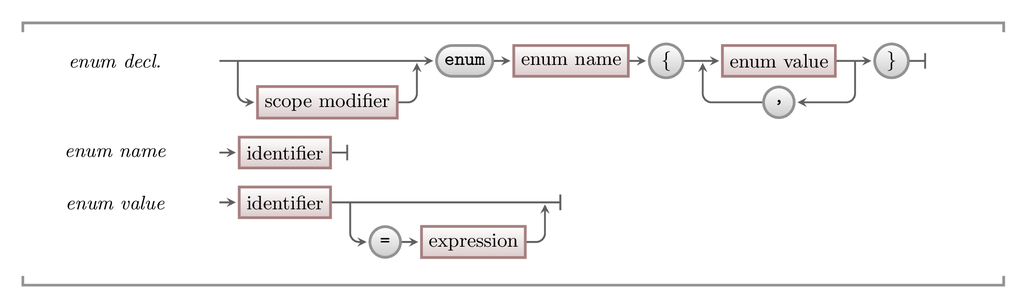

- The scope modifier controls who can use the enumeration: **public** means any object/class can call the enumeration, **private** means it can only be called from within the current scope.

```
public enum Nationality
{
  Australian, Italian, Estonian, Other
}
```

## While Loop

While loops are an important tool in programming, used to repeat code a number of time. They are a pre-test loop.

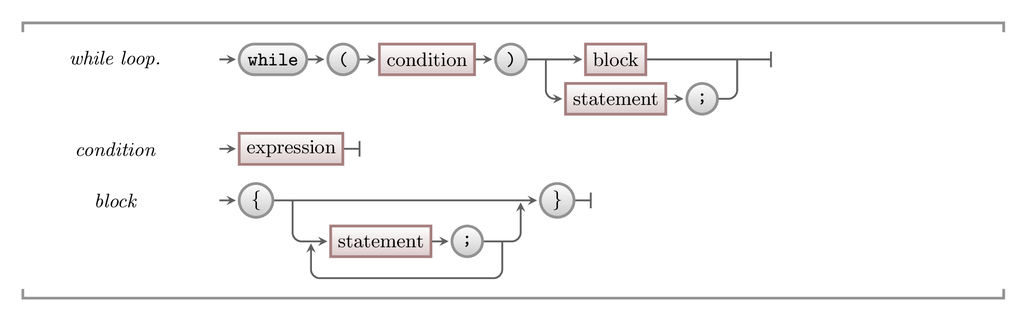

This diagram shows the syntax for a while loop in C#.

- The `condition` needs to evaluate to a **boolean** value (true or false).
- The block or statement is executed, and then control returns back to the condition to determine if the block/statement should run again.

```
int x = 0;

while( x < 100 )
{
  Console.WriteLine(x);
  x++;
}

while( x > 0 )
{
  Console.WriteLine(x);
  x--;
}
```

All while loops consist of the condition expression, in this case it is: `( x < 100 )`, and the body which will be executed many times: `Console.WriteLine(x);`

## Do While Loop

While loops are a pre-test loop, the *Do While* loop is a post-test loop. They operate almost exactly the same as while loops, however the condition is evaluated at the end of the body, this means they will always execute once.

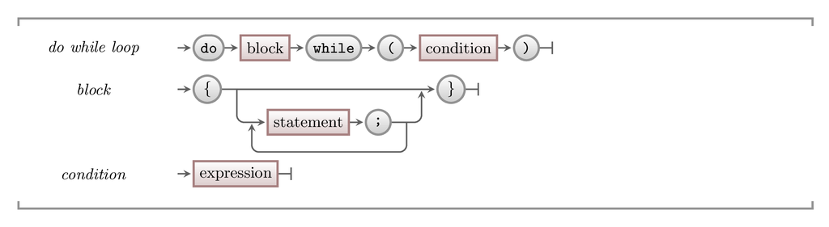

This diagram shows the syntax for a do while loop in C#.

- The `condition` needs to evaluate to a **boolean** value (true or false).
- The do while loop runs a block of code, at which point point it evaluates the boolean expression `x < 100`. If is value is true, then the loop is rerun, otherwise the program continues on.

```
int x = 0;

do
{
  Console.WriteLine(x);
  x++;
} while( x < 100 );

do
{
  Console.WriteLine(x);
  x--;
} while ( x > 0 );
```

All loops consist of the condition expression, in this case it is: `( x < 100 )`, and the body which will be executed many times: `Console.WriteLine(x);`

## Switch (Case Statement)

A switch statement allows you to compare a value against a list of possible values, and execute a block of code which matches the case.

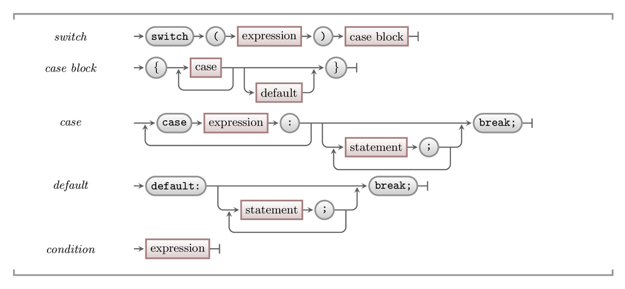

This diagram shows the syntax for a switch statement in C#.

- The switch statement can evaluate an expression of any type, and the case expressions need to match that type. For example, in the following code snippet, the `Nationality` property is of type `Nationality`, and each case is a `Nationality`.

```
switch (Nationality) //the property
{
  case Nationality.Australian:
    Console.WriteLine("Do you have a pet Kangaroo?");
    break;
  case Nationality.Italian:
    Console.WriteLine("Ciao!");
    break;
  case Nationality.Estonian:
    Console.WriteLine("Tere!");
    break;
  default:
    Console.WriteLine("Konichiwa");
    break;
}
```

In this example, if the `Nationality` property was Italian, "Ciao!" would be written out to the terminal.

Note the `break;` is needed in each case as to ensure you leave the case statement once you run the appropriate case block.

# Example Code

```
/// Program: PersonChecker
///
/// This jovial program evaluates a user's age, name and nationality
using System;
using System.IO;

namespace MyProgram
{

  public class Program
  {
    public static void Main()
    {
      Person p = new Person();
      p.EvaluateName();
      p.EvaluateAge();
      p.EvaluateNationality();
    }
  }
}

public enum Nationality
{
  Australian, Italian, Estonian, Other
}

public class Person
{
  public string Name { get; set; }
  public int Age { get; set; }
  public Nationality Nationality { get; set; }
  public bool IsOver18 { get; set; }

  public Person()
  {
    ReadPerson();
  }

  private void ReadNationality()
  {
    Console.Write("Please enter the person's nationality: ");
    string nationality = Console.ReadLine();

    switch (nationality.ToLower())
    {
      case "australian":
        Nationality = Nationality.Australian;
        break;
      case "italian":
        Nationality = Nationality.Italian;
        break;
      case "estonian":
        Nationality = Nationality.Estonian;
        break;
      default:
        Nationality = Nationality.Other;
        break;
    }
  }

  public void EvaluateNationality()
  {
    switch (Nationality)
    {
      case Nationality.Australian:
        Console.WriteLine("Do you have a pet Kangaroo?");
        break;
      case Nationality.Italian:
        Console.WriteLine("Ciao");
        break;
      case Nationality.Estonian:
        Console.WriteLine("Tere!");
        break;
      default:
        Console.WriteLine("Everyone is Welcome");
        break;
    }
  }

  public void ReadPerson()
  {
    try
    {
      Name = File.ReadAllText("name.txt");
    }
    catch
    {
      Console.WriteLine("Unable to open file");
      System.Environment.Exit(2);
    }

    Console.Write("Please enter the person's age: ");
    Age = Int32.Parse(Console.ReadLine());

    IsOver18 = Age > 18 ? true : false;

    ReadNationality();
  }

  public void EvaluateAge()
  {
    switch (Age)
    {
      case 42:
        Console.WriteLine("Awesome Age");
        break;
      case 1:
      case 2:
      case 3:
        Console.WriteLine("Wow you are young...");
        break;
      default:
        Console.WriteLine("Cool age.");
        break;
    }
  }

  public void EvaluateName()
  {
    if (Name == "Jake")
    {
      Console.WriteLine("Silly Name!!");
    }
    else if (Name == "Andrew")
    {
      Console.WriteLine("Really? Interesting name :)");
    }
    else
    {
      while (Name != "Jake" && Name != "Andrew")
      {
        Console.Write("Have we met? Try another name: ");
        Name = Console.ReadLine();
      }
      Console.WriteLine("Got there in the end.");
    }
  }
}
```